# Segmentación de prospectos con IA: cómo priorizar leads y validar tus clusters

Author

BI Evolution

## Resumen ejecutivo

¿Quieres saber **qué prospectos tienen más probabilidad de comprarte** y cómo hablarle a cada grupo? Este análisis segmenta tu base de leads en grupos **claros, accionables y listos para convertir**, permitiéndote:

- Priorizar esfuerzos comerciales donde hay **mayor intención de compra**.
- Ajustar mensaje, oferta y canal según cada perfil.
- Medir conversión y ticket por segmento para invertir mejor.

En BI Evolution usamos esta metodología para ayudar a empresas a **acelerar cierres y optimizar su fuerza comercial**.

## 1. Segmentos de prospectos: vista general

Antes de los detalles técnicos, aquí verás **cómo se agrupan tus prospectos** y qué significa cada segmento para tu negocio.

### 1.1. Cómo construimos la segmentación (explicación rápida)

Analizamos tus datos de **perfil** y **comportamiento digital** (visitas, emails, tiempo de respuesta) y entrenamos un modelo que identifica **5 segmentos naturales**, fáciles de gestionar y con patrones claros para tomar decisiones.

El objetivo: generar **insights accionables**, no solo estadísticas.

### 1.2. Cómo se ven tus segmentos (PCA visual)

Cada punto es un prospecto; cada color, un segmento. Esta visualización muestra de inmediato:

- Quiénes tienen **alto interés y actividad digital**.
- Quiénes avanzan rápido en la decisión.
- Quiénes necesitan nutrición o seguimiento suave.

Confirma que tu base **sí tiene patrones reales**, permitiendo estrategias comerciales diferenciadas.

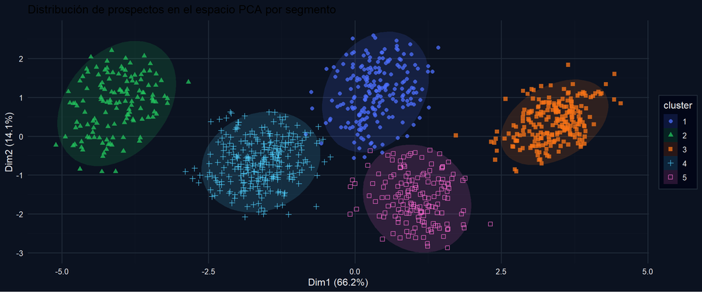

### 1.3. Qué significa este gráfico para tu negocio

Este gráfico resume toda la información de los prospectos en dos ejes que representan sus **comportamientos y características clave**.

- **Componente 1 (eje horizontal)**: comportamiento digital  
  (visitas web, aperturas de email, nivel de interés, interacción).
- **Componente 2 (eje vertical)**: perfil económico y velocidad de decisión  
  (ingresos, tiempo de respuesta, tiempo para decidir).

En otras palabras: el gráfico organiza a todos tus prospectos según **qué tan interesados están** y **qué tan listos están para avanzar en el proceso comercial**.

#### ¿Qué revela este gráfico?

- Los prospectos se agrupan en **nubes bien diferenciadas**, lo que confirma que existen **segmentos reales** dentro de tu base.
- Hay grupos con **alto comportamiento digital**, ideales para campañas rápidas de conversión.
- Otros grupos muestran **interacciones más bajas o decisiones más lentas**, donde funciona mejor un enfoque de nutrición (emails educativos, seguimientos suaves).
- Los colores separan **tipos de prospectos** con necesidades, ritmos e intereses diferentes.

#### ¿Por qué es valioso para tu empresa?

Porque este análisis permite:

- Priorizar el trabajo comercial en los segmentos que **más probabilidad de cierre** tienen.
- Diseñar mensajes más relevantes para cada grupo.
- Aumentar la conversión al atacar **cada tipo de prospecto con la estrategia adecuada**.
- Reducir esfuerzos y enfocar al equipo en quienes realmente pueden convertirse en clientes.

Este gráfico es, literalmente, tu **mapa estratégico** para saber cómo tratar a tus prospectos.

## 2. Perfiles de segmentos y oportunidades comerciales

> En esta sección traducimos la segmentación a **insights de negocio**: ¿qué caracteriza a cada cluster y cómo deberíamos gestionarlo comercialmente?

Resumen de perfiles por segmento de prospectos

| cluster_final | n | edad_media | ingresos_medios | nivel_interes_med | visitas_web_med | open_rate_med | email_score_med | tiempo_dec_med |
| --- | --- | --- | --- | --- | --- | --- | --- | --- |
| 1 | 208 | 41.14 | 4479.22 | 3.51 | 4.93 | 0.65 | 79.20 | 25.08 |
| 2 | 135 | 36.33 | 2103.19 | 1.54 | 1.56 | 0.32 | 52.44 | 29.91 |
| 3 | 226 | 44.39 | 6197.30 | 4.52 | 7.53 | 0.91 | 94.35 | 2.06 |
| 4 | 278 | 31.84 | 2544.26 | 2.47 | 4.97 | 0.52 | 66.68 | 13.78 |
| 5 | 153 | 32.62 | 3042.92 | 3.51 | 8.61 | 0.68 | 81.19 | 3.61 |

> A partir de esta tabla se pueden construir descripciones tipo:

### **Cluster 3 – Alto valor estratégico (premium)**

- Ingresos significativamente altos.
- Nivel de interés muy elevado.
- Muchas interacciones previas y alto email score.
- Decisión rápida: perfil ideal para cierre. **→ Recomendación:** campañas premium, upselling y contacto prioritario por ejecutivos senior.

### **Cluster 5 – Alto interés pero sensibles a objeciones**

- Altísimo volumen de visitas web y lectura activa de emails.
- Nivel de interés fuerte, ingresos medios.
- Decisiones rápidas pero comparan opciones. **→ Recomendación:** reforzar confianza: garantías, casos de éxito, beneficios claros y eliminación de fricciones.

Estos perfiles permiten definir **estrategias comerciales diferenciadas**, optimizar la conversión y priorizar esfuerzos donde hay mayor retorno.

## 3. ¿Con qué información se construyó la segmentación?

> Aquí mostramos de forma sencilla cómo luce la base utilizada para construir los segmentos.

### 3.1. Vista rápida de la base (columnas clave)

Muestra de prospectos y variables utilizadas en la segmentación

| edad | ingresos_mensuales | nivel_interes | tiempo_respuesta_min | interacciones_previas | visitas_web | open_rate | email_score | tiempo_decision_dias |
| --- | --- | --- | --- | --- | --- | --- | --- | --- |
| 34 | 2841 | 3 | 60 | 0 | 3 | 0.58 | 76 | 13 |
| 39 | 3291 | 4 | 11 | 1 | 7 | 0.51 | 79 | 1 |
| 42 | 2180 | 2 | 66 | 0 | 2 | 0.23 | 46 | 28 |
| 46 | 4521 | 3 | 32 | 4 | 5 | 0.56 | 72 | 32 |
| 44 | 5796 | 4 | 10 | 5 | 9 | 0.87 | 91 | 3 |
| 39 | 7483 | 4 | 9 | 6 | 8 | 0.89 | 90 | 1 |
| 47 | 7732 | 4 | 12 | 6 | 7 | 0.90 | 92 | 2 |
| 23 | 2250 | 3 | 4 | 3 | 8 | 0.85 | 89 | 5 |

## 4. ¿Cómo sabemos que los segmentos son confiables?

En esta parte respondemos la pregunta clave: **“¿No será que el modelo está ‘forzando’ grupos donde no los hay?”**

Para ello usamos métricas de:

- **Estabilidad del clustering** (APN, AD, ADM, FOM).
- **Calidad interna** (Silhouette, Dunn, Connectivity).

La lógica es la misma del script técnico de base; aquí solo mostramos resultados **resumidos** y explicados en tono ejecutivo.

### 4.1. Estabilidad de la segmentación (APN, AD, ADM, FOM)

Mejor combinación método–k según cada métrica de estabilidad

| Measure | Clusters | Method | Score |
| --- | --- | --- | --- |
| APN | 5 | kmeans | 0.008 |
| AD | 8 | kmeans | 1.829 |
| ADM | 5 | hierarchical | 0.025 |
| FOM | 5 | hierarchical | 0.470 |

### 4.2. Calidad interna de los clusters (Silhouette, Dunn, Connectivity)

Mejor combinación método–k según cada índice de calidad interna

| Measure | Clusters | Method | Score |
| --- | --- | --- | --- |
| Connectivity | 2 | hierarchical | 0.493 |
| Dunn | 7 | hierarchical | 0.213 |
| Silhouette | 5 | kmeans | 0.405 |

## 5. Próximos pasos sugeridos

1. **Marcar los prospectos** en el CRM con el `cluster_final`.
2. Definir **estrategias comerciales diferenciadas** por segmento (frecuencia de contacto, canal preferido, tipo de mensaje, ofertas).
3. Medir **conversión y ticket promedio** por cluster para validar el impacto.
4. Actualizar la segmentación de forma **trimestral o semestral** para incorporar nuevos datos y cambios en el comportamiento.